# Draft Report

Jay Bendre

01/03/2022

# Introduction

Covid-19 has managed to put this world to a complete stop and to date continues to be a thorn in our daily lives. With every day new variant and every day different mandates released by the local or federal governments has a direct correlation to the current low rates of cases and deaths being caused by the various variants. According to Stephanie Soucheray from CIDRAP, the covid cases have dropped by 40% ([CIDRAP](https://www.cidrap.umn.edu/news-perspective/2022/02/covid-19-cases-drop-40-us)) in the last week alone from the first week of February to the second week of February. This has led to the loosening up of the mask mandates and other mandates by various states across the US. It is interesting to check for the effect of these mandates on the overall covid death rates and the test case positives that are being generated and whether they truly have been effective in slowing down the extent of the spread of the virus. For the following project, the main effect would be to check if variables like restrictions on schools, workplace, income supports, debt/contract reliefs have any effect on the death rate during the peak of covid ie. during the identified waves of this covid virus.

#### Main question to be answered:

Do the mandates being imposed by the federal government across multiple countries have significant effect on the overall case fatality rate. The mandates could be restrictions on international travel, closing of schools, debt/contract relief etc. The response metric is defined as following:

$$Y_{CFR} = \frac{\text{Total Deaths}}{\text{Total Cases}}$$

# Dataset used

The data being proposed to be used in the following project mainly comes from 2 sources:

#### * WHO Covid Data (WHO Data)

- The data obtained is gathered from the WHO Health Emergency Dashboard. It is an open-source dataset consisting of data pertaining to the number of cases and deaths that have occured over the past 2 years and arranged in a time-series capacity.
- The table below shows all the important variables important in the dataset.

| Variable Name | Variable Data type | Variable Description |
| --- | --- | --- |
| Date Reported | Timestamp | Timestamp of data collection |
| Country Code | Factor | Abbreviation of the Country name |
| Country | Factor | Country name |
| WHO Region | Factor | Identifies various WHO regions |
| New Cases | Quantitative | Number of new cases |
| Cumulative Cases | Quantitative | Sum of cases till the given date |
| New Deaths | Quantitative | Number of new deaths |
| Cumulative Deaths | Quantitative | Sum of deaths till the given date |

#### * OxCGRT Dataset ([Oxford Data](https://github.com/OxCGRT/covid-policy-tracker))

- The data contained takes a look at many of the policies and mandates imposed by federal governments across entire nations.
- Few of such mandates that could be interesting to look at are as follows

  | Variable Name | Variable Data type | Variable Description |
  | --- | --- | --- |
  | Date | Timestamp | Timestamp of data collection |
  | C1 | Factor | Indicator for School Closures |
  | C2 | Factor | Indicator for Workplace Closures |
  | C6 | Factor | Indicator for Stay at Home order |
  | C8 | Factor | Indicator for Internation Travel Restrictions |
  | E1 | Factor | Indicator for Income Support |
  | E2 | Factor | Indicator for Debt/Contract Relief |
  | H3 | Factor | Indicator for Contact Tracing |
  | H7 | Factor | Indicator for Vaccination Policy |
  | V2A | Factor | Indicator for Vaccination Availability |

# Exploratory Data Analysis (In Progress)

The purpose of performing EDA on the datasets is to gain insights into the dataset and confirm an intuition that we can observe based on the trends we plot.

```r
# Loading the datasets being used

covid <- read_csv("https://covid19.who.int/WHO-COVID-19-global-data.csv")

oxford <- read_csv("OxCGRT_latest.csv")

# Selecting the neccessary variables from the dataset
oxford <- oxford %>% select(c("Date","CountryName","C1_School closing", "C2_Workplace closing", "C6_Stay at home requirements", "C8_International travel controls", "E1_Income support", "E2_Debt/contract relief", "H3_Contact tracing", "H7_Vaccination policy", "V2A_Vaccine Availability (summary)"))

covid %>% head()
```

```
## # A tibble: 6 x 8
##   Date_reported Country_code Country     WHO_region New_cases Cumulative_cases
##   <date>        <chr>        <chr>       <chr>          <dbl>            <dbl>
## 1 2020-01-03    AF           Afghanistan EMRO               0                0
## 2 2020-01-04    AF           Afghanistan EMRO               0                0
## 3 2020-01-05    AF           Afghanistan EMRO               0                0
## 4 2020-01-06    AF           Afghanistan EMRO               0                0
## 5 2020-01-07    AF           Afghanistan EMRO               0                0
## 6 2020-01-08    AF           Afghanistan EMRO               0                0
## # ... with 2 more variables: New_deaths <dbl>, Cumulative_deaths <dbl>
```

```r
oxford %>% head()
```

```
## # A tibble: 6 x 11
##       Date CountryName `C1_School closing` `C2_Workplace clo~ `C6_Stay at home ~
##      <dbl> <chr>                     <dbl>              <dbl>              <dbl>
## 1 20200101 Aruba                         0                  0                  0
## 2 20200102 Aruba                         0                  0                  0
## 3 20200103 Aruba                         0                  0                  0
## 4 20200104 Aruba                         0                  0                  0
## 5 20200105 Aruba                         0                  0                  0
## 6 20200106 Aruba                         0                  0                  0
## # ... with 6 more variables: C8_International travel controls <dbl>,
## #   E1_Income support <dbl>, E2_Debt/contract relief <dbl>,
## #   H3_Contact tracing <dbl>, H7_Vaccination policy <dbl>,
## #   V2A_Vaccine Availability (summary) <dbl>
```

```r
# Handling for variable types in the dataset

covid$Country_code <- as.factor(covid$Country_code)
covid$WHO_region <- as.factor(covid$WHO_region)
covid$Country <- as.factor(covid$Country)
# Looking for missing values in the dataset and decide a
# strategy to handle it
sapply(covid, function(x) sum(is.na(x)))
```

```
##     Date_reported      Country_code           Country        WHO_region
##                 0              1584                 0                 0
##         New_cases  Cumulative_cases        New_deaths Cumulative_deaths
##                 0                 0                 0                 0
```

```r
# We observe that for no country code we may still have corresponding country information so we could either use the country code or the country name, it wont change the analaysis to be conduted

covid <- covid %>% select(-c(Country_code))
```

```r
# Performing descriptive analysis on the available data
summary(covid)
```

```
##  Date_reported                  Country       WHO_region      New_cases
##  Min.   :2020-01-03   Afghanistan   :   792   AFRO :39600   Min.   : -32952
##  1st Qu.:2020-07-18   Albania       :   792   AMRO :44352   1st Qu.:      0
##  Median :2021-02-01   Algeria       :   792   EMRO :17424   Median :     22
##  Mean   :2021-02-01   American Samoa:   792   EURO :49104   Mean   :   2348
##  3rd Qu.:2021-08-18   Andorra       :   792   Other:  792   3rd Qu.:    501
##  Max.   :2022-03-04   Angola        :   792   SEARO: 8712   Max.   :1294289
##                       (Other)       :182952   WPRO :27720
##  Cumulative_cases     New_deaths      Cumulative_deaths
##  Min.   :       0   Min.   : -60.00   Min.   :     0
##  1st Qu.:     139   1st Qu.:   0.00   1st Qu.:     1
##  Median :    8990   Median :   0.00   Median :   125
##  Mean   :  521116   Mean   :  31.85   Mean   : 10694
##  3rd Qu.:  137969   3rd Qu.:   6.00   3rd Qu.:  2385
##  Max.   :78428884   Max.   :8786.00   Max.   :947625
##
```

```r
summary(oxford)
```

```
##       Date          CountryName        C1_School closing C2_Workplace closing
##  Min.   :20200101   Length:243360      Min.   :0.000     Min.   :0.000
##  1st Qu.:20200714   Class :character   1st Qu.:1.000     1st Qu.:1.000
##  Median :20210124   Mode  :character   Median :1.000     Median :1.000
##  Mean   :20206571                      Mean   :1.561     Mean   :1.356
##  3rd Qu.:20210807                      3rd Qu.:3.000     3rd Qu.:2.000
##  Max.   :20220218                      Max.   :3.000     Max.   :3.000
##                                        NA's   :5972      NA's   :5949
##  C6_Stay at home requirements C8_International travel controls
##  Min.   :0.000                Min.   :0.000
##  1st Qu.:0.000                1st Qu.:1.000
##  Median :1.000                Median :3.000
##  Mean   :0.908                Mean   :2.469
##  3rd Qu.:2.000                3rd Qu.:3.000
##  Max.   :3.000                Max.   :4.000
##  NA's   :6045                 NA's   :7046
##  E1_Income support E2_Debt/contract relief H3_Contact tracing
##  Min.   :0.000     Min.   :0.000           Min.   :0.000
##  1st Qu.:0.000     1st Qu.:0.000           1st Qu.:1.000
##  Median :1.000     Median :1.000           Median :2.000
##  Mean   :0.798     Mean   :0.921           Mean   :1.408
##  3rd Qu.:1.000     3rd Qu.:2.000           3rd Qu.:2.000
##  Max.   :2.000     Max.   :2.000           Max.   :2.000
##  NA's   :6449      NA's   :6337            NA's   :10379
##  H7_Vaccination policy V2A_Vaccine Availability (summary)
##  Min.   :0.000         Min.   :0.00
##  1st Qu.:0.000         1st Qu.:0.00
##  Median :0.000         Median :0.00
##  Mean   :1.891         Mean   :0.75
##  3rd Qu.:4.000         3rd Qu.:1.00
##  Max.   :5.000         Max.   :3.00
##  NA's   :9966          NA's   :86203
```

Next based on the collected data we need to feature engineer the main response variable $CFR$ that’s not readily available in the current datasets.

```r
# Generating the CFR variable
# CFR is described as cumulative deaths/cumulative cases
cfr <- function(x){
    if(x[1]== 0){
        return(0)
    }
    else
    {
        return(x[2]/x[1])
    }
}

covid$CFR <- apply(covid[,c("Cumulative_cases","Cumulative_deaths")],1,cfr)
```

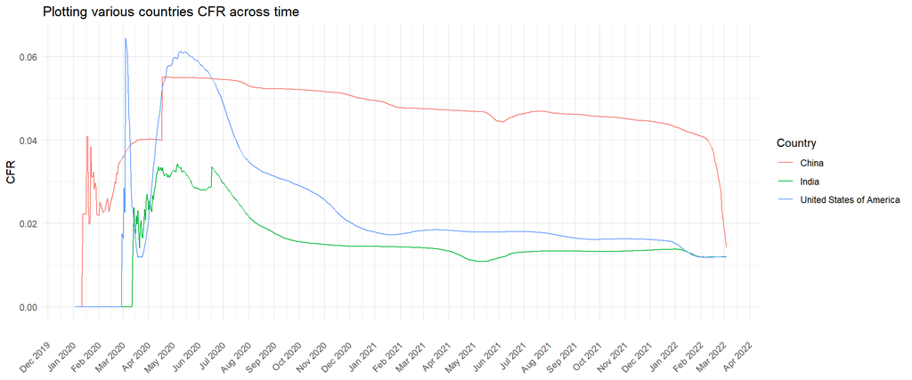

```r
# Observing trends based on the CFR variable
#1. Generating a timeseries plot for the CFR variable for US

countries <- c("United States of America", "India", "China")
comparision_data <- covid %>% filter(Country %in% countries)


ggplot(comparision_data, aes(x = Date_reported, y = CFR, color = Country)) + geom_line() + scale_x_date(date_breaks = "1 month",date_labels = "%b %Y")+ ggtitle("Plotting various countries CFR across time") + xlab("") + ylab("CFR")+ theme_minimal()+ theme(axis.text.x = element_text(angle = 45, vjust = 0.5, hjust=1))
```

It is interesting to observe a few things from the CFR plot that we have gotten here. Overall the CFR rate for India is lower than it was for in case of US but China seems to have the highest CFR rate. We can also notice high peaks during the initial inception of the mandates ie. around March 2020 where the CFR rates spike up exponentially. It would not be too far out to assume the plateau that we can see in the CFR during August 2020 was due to the successful implementation of all the mandates applied.

We can look at the number of new cases that China got on a weekly basis and understand the higher CFR rates than the other countries being plotted above.

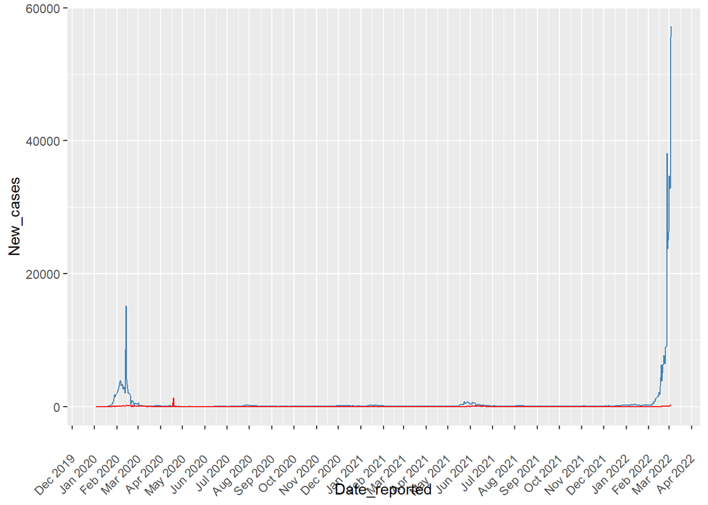

```r
china_data <- covid %>% filter(Country == "China")

ggplot(china_data, aes(x = Date_reported)) + geom_line(aes(y = New_cases), color = "steelblue") + geom_line(aes(y = New_deaths ),color = "red") + scale_x_date(date_breaks = "1 month", date_labels = "%b %Y") + theme(axis.text.x = element_text(angle = 45, vjust = 0.5, hjust=1))
```

Let’s look at all the mandates that we wanna consider and find a date at which they happened and see the difference in the CFR rate pre and post implementing of these as well. Let’s look at international travel ban and its potential impact on the CFR rate in the United States.

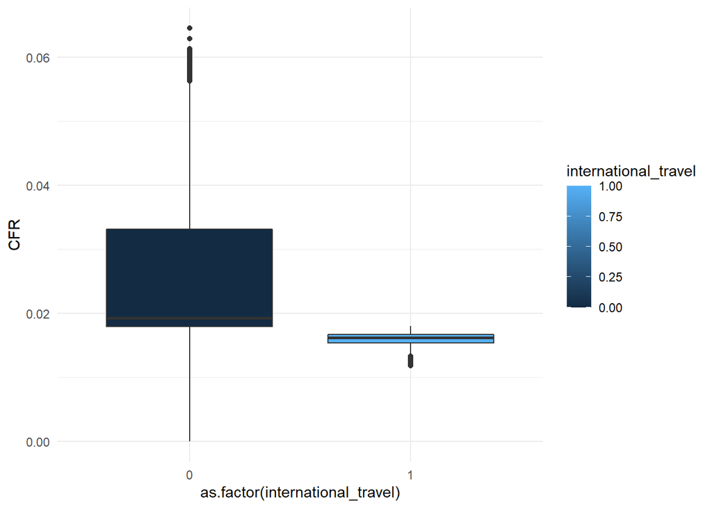

```r
# Getting a date when the value changed for the international travel ban
us_oxford <- oxford %>% filter(CountryName == "United States")
dateChange <- us_oxford$Date[c(FALSE, diff(as.numeric(us_oxford$`C8_International travel controls`)) > 0)][3]
year <- substr(toString(dateChange),1,4)
month <- substr(toString(dateChange),5,6)
day <- substr(toString(dateChange),7,8)
date <- paste(year ,"-", month ,"-" , day, sep = "")

us_data <- covid %>% filter(Country == "United States of America")
# Creating 2 samples for pre and post ban of international travel
us_data_pre_ban <- us_data %>% filter(Date_reported < as.Date(date))
us_data_pre_ban$international_travel <- 0

us_data_post_ban <- us_data %>% filter(Date_reported >= as.Date(date))
us_data_post_ban$international_travel <- 1


# Binding together with the introduction of the indicator variable
us_data <- rbind(us_data_pre_ban, us_data_post_ban)
ggplot(us_data, aes(x = as.factor(international_travel), y = CFR, fill = international_travel)) + geom_boxplot() + theme_minimal()
```

# Methodology

One of the approaches to use to solve this kind of problem would be to divide the dataset into various covid waves and analyze them separately as a regression model. In econometrics this techqnique is known as a panel regression. In a panel regression setting, we divide timeseries data into acceptable samples and perform linear regression on those specific samples. The reason of choosing this method will help us analyze the CFR rate before and after implementation of a particular mandate by the Federal Governments.

Panel regression is a modeling method adapted to panel data, also called longitudinal data or cross-sectional data. It is widely used in econometrics, where the behavior of statistical units (i.e. panel units) is followed across time. Those units can be firms, countries, states, etc. Panel regression allows controlling both for panel unit effect and for time effect when estimating regression coefficients.  
Panel data regression is a powerful way to control dependencies of unobserved, independent variables on a dependent variable, which can lead to biased estimators in traditional linear regression models

In general, a Panel regression equation is given by,

$$Y_{it} = X_{it}\beta + \alpha_i + \mu_{it}$$

where

- Y = Response Variable
- X = Dependent Variables
- $\beta$ = Regression Coefficients
- $\alpha$ = Individual Effects
- $\mu$ = Idiosyncratic Error

# Roadmap

This section describes the upcoming plan that would take place in completion of the project before the expected delivery. The plan can be divided into week by week plans.

#### Week 8

- Deciding on appropriate variables for modelling
- Exploring Panel Regression and understanding its correlation with the current question that needs to be answered.
- Identifying other data sources that could be useful in helping answer the question.

#### Week 9

- Have an agreeable statistical model ready to be presented in the draft report.
- Coordinate with the TA to gather more information and direction for the project.
- Completion and submission of a draft report and get feedback on it for the same.

#### Week 10 (Submission Week)

- Confirm the problem statement, methodology and any potential discrepancies in the problem.
- Corroborate with the group members and compare the results obtained by working and create a Quasi- experimemtal approaches and incorporate it in the final report
- Proof read and finalize the report to be submitted and work on the presentation.

# Acknowledgement

Collaborated with the team members of team 5.